```python
import sklearn
print(sklearn.__version__)
```

```
1.0.2
```

```python
import numpy as np
import pandas as pd
import matplotlib.pyplot as plt
#put indicator index into one dataframe
df_indicator = pd.read_excel('Data2.0.xlsx', sheet_name= 'Indicators')
df_indicator = df_indicator.set_index('Dates')
df_indicator=df_indicator.rename(columns={'SPX Index':'S&P500'})
df_indicator
#put Monthly Instrument into one dataframe
df_instrument_1=pd.read_excel('Data2.0.xlsx', sheet_name= 'Instruments')
df_instrument_1 = df_instrument_1.set_index('Dates')
df_instrument_1=df_instrument_1.rename(columns={'M1USMMT Index':'MSCI US Momentum index',
                              'M1USQU Index':'MSCI US Quality index',
                              'M00IMV$T Index':'MSCI US Min Vol index',
                              'M1US000V Index':'MSCI US Value index',
                              'M1US000G Index':'MSCI US Growth index',
                              'RTY Index':'Russell 2000',
                              'LBUSTRUU Index':'US IG corporate bonds index',
                              'SPGSCI Index':'GSCI commodity index'})
df_instrument_1
#df_logReturn = df_instrument_1.applymap(lambda x: np.log(float(x))) - df_instrument_1.shift().applymap(lambda x: np.log(float(x)))

#clean the US 10Y and 3_month bond data
df_Bond = pd.read_excel('Data2.0.xlsx', sheet_name= 'Bonds')
df_Bond = df_Bond.set_index('Dates')
df_Bond=df_Bond.rename(columns={'SPBDU1BT Index':'US 10-year Treasury Bond Index',
                              'SPBDUB3T Index':'US 3-month T-bill Index'})


df_instrument= df_instrument_1.merge(df_Bond, left_index=True, right_index=True, how = 'left')


df_logReturn = df_instrument.applymap(lambda x: np.log(float(x))) - df_instrument.shift().applymap(lambda x: np.log(float(x)))
df_logReturn
#df_instrument_yearly log return
df_instrument_yearly = df_instrument.resample('Y').ffill()
df_instrument_Q = df_instrument.resample('Q').ffill()
df_instrument_6M = df_instrument.resample('6M').ffill()

#df_instrument_yearly = df_instrument_yearly.merge(df_10YBond, left_index=True, right_index=True, how = 'left')
#df_instrument_yearly = df_instrument_yearly.merge(df_3MBond, left_index=True, right_index=True, how = 'left')
df_logReturnYearly = df_instrument_yearly.applymap(lambda x: np.log(float(x))) - df_instrument_yearly.shift().applymap(lambda x: np.log(float(x)))
df_logReturnQ = df_instrument_Q.applymap(lambda x: np.log(float(x))) - df_instrument_Q.shift().applymap(lambda x: np.log(float(x)))
df_logReturn6m = df_instrument_6M.applymap(lambda x: np.log(float(x))) - df_instrument_6M.shift().applymap(lambda x: np.log(float(x)))
#df_logReturnYearly


############ Regime Finding ##########
import matplotlib.pyplot as plt
df_used = df_logReturn.merge(df_indicator, left_index = True, right_index = True, how = 'left').dropna()
df_used['CPI'] = df_used['CPI'].pct_change()
df_used['PMI'] = df_used['PMI'].pct_change()
df_used['S&P500'] = df_used[['S&P500']].applymap(lambda x: np.log(float(x))) - df_used[['S&P500']].shift().applymap(lambda x: np.log(float(x)))

import warnings
warnings.filterwarnings("ignore")
df_used = df_used.dropna()
```

# Market Regime

Part 1: Generate Nine Indicator for market regime.</b>

```python
#import plotly.express as px
df_features = df_used[['US 3-month T-bill Index', 'S&P500', 'VIX Index']].ewm(span = 5).mean()
df_features.loc[:, 'S&P500_Change'] = df_features['S&P500'].diff(3)
df_features.loc[:, 'S&P500_Last'] = df_features['S&P500'].shift()
df_features.loc[:, 'T3_Change'] = df_features['US 3-month T-bill Index'].diff(3)
df_features.loc[:, 'VIX_Change'] = df_features['VIX Index'].diff(3)
df_features.loc[:, 'CPI_PMI'] = df_used['CPI'] + df_used['PMI']
df_features.loc[:, 'CPI_PMI_Change'] = df_features['CPI_PMI'].diff(3)
df_features = df_features.shift(1).dropna()
```

Part 2: Split data into training, testing data.</b>

```python
import pandas as pd
from sklearn.model_selection import train_test_split

# Assuming df is your DataFrame
indices = df_features.index

# randomly Split indices into training (80%), and testing (20%)
train_indices, test_indices = train_test_split(indices, test_size=0.2, random_state=3)



# Use the indices to subset the original DataFrame
train_df = df_features.loc[train_indices].sort_index()
test_df = df_features.loc[test_indices].sort_index()
```

Part 3: Standardized Indicators of market regimes.</b>

```python
from sklearn.preprocessing import StandardScaler
scaler = StandardScaler()
scaled_train = scaler.fit_transform(train_df)
scaled_train = pd.DataFrame(scaled_train, columns=train_df.columns, index = train_df.index)
scaled_train
```

| Dates | US 3-month T-bill Index | S&P500 | VIX Index | S&P500_Change | S&P500_Last | T3_Change | VIX_Change | CPI_PMI | CPI_PMI_Change |
| --- | --- | --- | --- | --- | --- | --- | --- | --- | --- |
| 1995-08-31 | 1.646815 | 1.082261 | -1.194485 | 0.063593 | 0.991971 | 1.142346 | 0.174797 | -0.202952 | -0.247982 |
| 1995-09-29 | 1.626381 | 0.539999 | -1.256570 | -0.621402 | 1.077359 | -0.509362 | -0.103626 | -0.333278 | -0.077899 |
| 1995-10-31 | 1.506219 | 0.924437 | -1.224536 | -0.052609 | 0.535179 | -0.788007 | 0.078578 | 0.428538 | 0.478412 |
| 1995-11-30 | 1.573772 | 0.399970 | -1.145589 | -0.589756 | 0.919559 | -0.306584 | 0.042723 | -0.262063 | -0.077767 |
| 1996-01-31 | 1.573423 | 0.724521 | -1.211081 | -0.164899 | 0.823988 | 0.391426 | -0.017662 | 0.441011 | -0.024603 |
| ... | ... | ... | ... | ... | ... | ... | ... | ... | ... |
| 2022-11-30 | -0.142047 | -0.424373 | 1.015255 | -0.134673 | -2.346866 | 3.092229 | 0.409362 | -0.590266 | 0.952038 |
| 2023-01-31 | 0.475500 | -0.781832 | 0.526324 | 1.385741 | 0.453843 | 3.721207 | -1.015696 | 1.560665 | 0.520492 |
| 2023-02-28 | 0.570202 | 0.342620 | 0.302084 | 0.686715 | -0.786449 | 3.601853 | -1.255678 | -0.001824 | 0.403162 |
| 2023-03-31 | 0.703895 | -0.304285 | 0.219121 | -0.660784 | 0.337831 | 2.783833 | -0.840184 | -0.448240 | 1.866823 |
| 2023-04-28 | 0.931695 | 0.249206 | 0.061458 | 0.919274 | -0.308975 | 2.327458 | -0.832618 | -0.192484 | -1.335905 |

268 rows × 9 columns

```python
scaled_test = pd.DataFrame(scaler.transform(test_df), columns = test_df.columns, index = test_df.index)
```

Part 4: K Means to Cluster 4 Market Regime.</b>

```
No artists with labels found to put in legend.  Note that artists whose label start with an underscore are ignored when legend() is called with no argument.
```

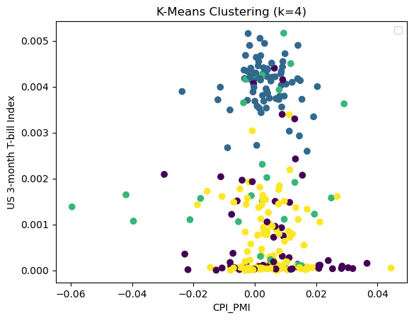

```python
from sklearn.cluster import KMeans
import matplotlib.pyplot as plt

# Number of clusters
k = 4

# Fit K-Means model
kmeans = KMeans(n_clusters=k, random_state=1)
kmeans.fit(scaled_train)

# Add cluster labels to the DataFrame
train_df['Cluster'] = kmeans.labels_

# Visualize the clusters (for 2D data)
plt.scatter(train_df['CPI_PMI'], train_df['US 3-month T-bill Index'], c=train_df['Cluster'], cmap='viridis')
#plt.scatter(kmeans.cluster_centers_[:, 0], kmeans.cluster_centers_[:, 1], s=300, c='red', label='Centroids')
plt.xlabel('CPI_PMI')
plt.ylabel('US 3-month T-bill Index')
plt.title('K-Means Clustering (k=4)')
plt.legend()
plt.show()
```

```python
df_instrument['Cluster'] = train_df['Cluster']
```

Part 5: Different Market Regime on SP500 Price Trend Chart.</b>

```python
import plotly.express as px
fig = px.scatter(df_instrument.loc[train_df.index], x=train_df.index, y=df_indicator.loc[train_df.index, 'S&P500'], color = 'Cluster')

# Customize the plot
#fig.update_traces(textposition='top center', textfont_size=10)

# Set axis labels and plot title
fig.update_layout(xaxis_title='Time', yaxis_title='S&P500', title='Scatter Plot of S&P500')

# Show the plot
fig.show()
```

[interactive chart not shown]

```python
regimeDic = {1:'SlowDown', 2:'Contraction', 3:'Expansion', 0:'Recovery'}
```

Part 6: Assign weights based on regime.</b>

```python
def getRegimeInfo(df_logReturn, train_df):
    df_out_all = pd.DataFrame()
    for regime in range(4):
        df = df_logReturn.loc[train_df[train_df['Cluster'] == regime].index]
        df['Benchmark'] = df.mean(axis = 1)
        mean_r = 12*df.dropna().mean()
        sigma_r = np.sqrt(12)*df.dropna().std()
        mean_r_rm = 12*df.sub(df['Benchmark'], axis = 0).dropna().mean()
        sigma_r_rm = np.sqrt(12)*df.sub(df['Benchmark'], axis = 0).dropna().std()
        sharpe_ratio = (mean_r)/ (sigma_r)
        info_ratio = (mean_r_rm)/ (sigma_r_rm)
        df_out = pd.DataFrame(columns = df.columns)
        df_out.loc['Mean Return'] = mean_r
        df_out.loc['Return Std'] = sigma_r
        df_out.loc['Mean Excess Return'] = mean_r_rm
        df_out.loc['Info Std'] = sigma_r_rm
        df_out.loc['Sharpe Ratio'] = sharpe_ratio
        df_out.loc['Info Ratio'] = info_ratio
        df_out['Regime'] = regimeDic[regime]
        df_out_all = pd.concat((df_out_all, df_out))
    return df_out_all.fillna(0)

regimeDf = getRegimeInfo(df_logReturn, train_df)
```

```python
import plotly.graph_objects as go
from plotly.subplots import make_subplots

# Create subplots with 2 rows and 2 columns
fig = make_subplots(rows=1, cols=4, subplot_titles=['Expansion', 'SlowDown', 'Contraction', 'Recovery'])

for i, regime_name in enumerate(['Expansion', 'SlowDown', 'Contraction', 'Recovery']):
    info_ratio = regimeDf[regimeDf['Regime'] == regime_name].loc[['Info Ratio']].drop(['Benchmark', 'Regime'], axis=1)

    # Add a bar trace to the subplot
    trace = go.Bar(x=info_ratio.columns, y=info_ratio.loc['Info Ratio'], name='Info Ratio')
    row = 1
    col = i + 1
    fig.add_trace(trace, row=row, col=col)
fig.update_layout(width=1200, height=600)
# Update layout
fig.update_layout(title_text='Info Ratio of Different Regimes', showlegend=False)

# Show the plot
fig.show()
```

[interactive chart not shown]

```python
def getRegimeWeights(df_logReturn, train_df):
    df_out_all = pd.DataFrame()
    for regime in range(4):
        df = df_logReturn.loc[train_df[train_df['Cluster'] == regime].index]
        df['Benchmark'] = df.mean(axis = 1)
        mean_r = 12*df.dropna().mean()
        sigma_r = np.sqrt(12)*df.dropna().std()
        mean_r_rm = 12*df.sub(df['Benchmark'], axis = 0).dropna().mean()
        sigma_r_rm = np.sqrt(12)*df.sub(df['Benchmark'], axis = 0).dropna().std()
        sharpe_ratio = (mean_r)/ (sigma_r)
        info_ratio = (mean_r_rm)/ (sigma_r_rm)
        df_out = pd.DataFrame(columns = df.columns)
        df_out.loc['Mean Return'] = mean_r
        df_out.loc['Return Std'] = sigma_r
        df_out.loc['Mean Excess Return'] = mean_r_rm
        df_out.loc['Info Std'] = sigma_r_rm
        df_out.loc['Sharpe Ratio'] = sharpe_ratio
        df_out.loc['Info Ratio'] = info_ratio
        df_out['Regime'] = regimeDic[regime]
        df_out_all = pd.concat((df_out_all, df_out))
    regime_df = df_out_all
    #return regime_df
    info_regime = regime_df.loc['Info Ratio'].set_index(['Regime']).applymap(lambda x: np.exp(float(x))).drop('Benchmark', axis = 1)
    regime_score = info_regime.div(info_regime.sum(axis = 1), axis = 0)
    return regime_score
```

```python
regime_weights = getRegimeWeights(df_logReturn, train_df)
regime_weights
```

| Regime | MSCI US Momentum index | MSCI US Quality index | MSCI US Min Vol index | MSCI US Value index | MSCI US Growth index | Russell 2000 | US IG corporate bonds index | GSCI commodity index | US 10-year Treasury Bond Index | US 3-month T-bill Index |
| --- | --- | --- | --- | --- | --- | --- | --- | --- | --- | --- |
| Recovery | 0.071019 | 0.133981 | 0.180651 | 0.154913 | 0.093844 | 0.087298 | 0.056350 | 0.118435 | 0.059236 | 0.044275 |
| SlowDown | 0.250368 | 0.173097 | 0.080563 | 0.084015 | 0.137141 | 0.104904 | 0.028803 | 0.086934 | 0.028152 | 0.026024 |
| Contraction | 0.035245 | 0.050123 | 0.040353 | 0.032216 | 0.029628 | 0.037929 | 0.287436 | 0.021663 | 0.289718 | 0.175691 |
| Expansion | 0.148794 | 0.211671 | 0.125321 | 0.084302 | 0.208537 | 0.070824 | 0.029783 | 0.064246 | 0.032998 | 0.023524 |

Part 7: Predict regime (which cluster(4) the data close to will be predicted regime).</b>

```python
def getRegimePredict(df_features):
    scaled_valid = pd.DataFrame(scaler.transform(df_features), columns = df_features.columns, index = df_features.index)
    # Add cluster labels to the DataFrame
    scaled_valid['Cluster'] = kmeans.predict(scaled_valid)

    scaled_valid['Regime'] = scaled_valid['Cluster'].map(regimeDic)
    return scaled_valid[['Cluster', 'Regime']]
```

```python
#validate prediction method and plot
regimes = getRegimePredict(df_features[df_features.index.isin(test_df.index)])
#show the market regime into SP 500 trend
fig = px.scatter(df_instrument.loc[regimes.index], x=regimes.index, y=df_indicator.loc[regimes.index, 'S&P500'], color = regimes['Cluster'])

# Set axis labels and plot title
fig.update_layout(xaxis_title='Time', yaxis_title='S&P500', title='Scatter Plot of S&P500')

# Show the plot
fig.show()
```

[interactive chart not shown]

```python
#validate prediction method and plot
regimes = getRegimePredict(df_features)
#show the market regime into SP 500 trend
fig = px.scatter(df_instrument.loc[regimes.index], x=regimes.index, y=df_indicator.loc[regimes.index, 'S&P500'], color = regimes['Cluster'])

# Set axis labels and plot title
fig.update_layout(xaxis_title='Time', yaxis_title='S&P500', title='Scatter Plot of S&P500')

# Show the plot
fig.show()
```

[interactive chart not shown]

```python
# regimeDf = getRegimeInfo(df_logReturn, regimes)

# import plotly.graph_objects as go
# from plotly.subplots import make_subplots

# # Create subplots with 2 rows and 2 columns
# fig = make_subplots(rows=1, cols=4, subplot_titles=['Expansion', 'SlowDown', 'Contraction', 'Recovery'])

# for i, regime_name in enumerate(['Expansion', 'SlowDown', 'Contraction', 'Recovery']):
#     info_ratio = regimeDf[regimeDf['Regime'] == regime_name].loc[['Info Ratio']].drop(['Benchmark', 'Regime'], axis=1)

#     # Add a bar trace to the subplot
#     trace = go.Bar(x=info_ratio.columns, y=info_ratio.loc['Info Ratio'], name='Info Ratio')
#     row = 1
#     col = i + 1
#     fig.add_trace(trace, row=row, col=col)
# fig.update_layout(width=1600, height=600)
# fig.update_yaxes(range=[-1.5, 1.5])
# # Update layout
# fig.update_layout(title_text='Info Ratio of Different Regimes', showlegend=False)

# # Show the plot
# fig.show()
```

```python
regimes
```

| Dates | Cluster | Regime |
| --- | --- | --- |
| 1995-08-31 | 1 | SlowDown |
| 1995-09-29 | 1 | SlowDown |
| 1995-10-31 | 1 | SlowDown |
| 1995-11-30 | 1 | SlowDown |
| 1995-12-29 | 1 | SlowDown |
| ... | ... | ... |
| 2023-03-31 | 1 | SlowDown |
| 2023-04-28 | 1 | SlowDown |
| 2023-05-31 | 1 | SlowDown |
| 2023-06-30 | 1 | SlowDown |
| 2023-07-31 | 1 | SlowDown |

336 rows × 2 columns

```python
df_regime_weights = regimes.merge(regime_weights, left_on = 'Regime', right_index = True, how = 'left')
df_regime_weights = df_regime_weights.drop(['Cluster', 'Regime'], axis = 1)
```

# Momentum

Part 1: 4 linearegression model by using 1,3,6,12 month moving average return variable.</b>

```python
#ret_mom_3m = df_logReturn.rolling(window=3, min_periods=1).mean().shift(1)
#mom_exp = np.exp(20 * ret_mom_3m.dropna())
#df_mom_weights = mom_exp.div(mom_exp.sum(axis=1), axis=0)
#df_mom_weights
```

```python
ret_mom_1m = df_logReturn.shift(1)
ret_mom_3m = df_logReturn.rolling(window=3, min_periods=1).mean().shift(1)
ret_mom_6m = df_logReturn.rolling(window=6, min_periods=1).mean().shift(1)
ret_mom_12m = df_logReturn.rolling(window=12, min_periods=1).mean().shift(1)
ret_next = df_logReturn
```

```python
import pandas as pd
from sklearn.linear_model import LinearRegression

# Define the lookback periods
lookback_periods = [1, 3, 6, 12]

# Initialize an empty DataFrame for coefficients
mom_coefs = pd.DataFrame()

for period in lookback_periods:
    mom_col_name = f'mom_{period}m'
    mom_coef = pd.DataFrame(columns=['intercept', mom_col_name])

    for column in df_logReturn.columns:
        ret_mom = pd.concat((globals()[f'ret_mom_{period}m'][column], ret_next[column]), axis=1).dropna()
        ret_mom.columns = [mom_col_name, 'ret_next']
        ret_mom_train = ret_mom.loc[train_df.index]
        X = ret_mom_train[[mom_col_name]]
        y = ret_mom_train['ret_next']

        # Initialize the Linear Regression model
        model = LinearRegression()

        # Fit the model to the data
        model.fit(X, y)

        # Get the coefficients
        coefficients = model.coef_
        intercept = model.intercept_

        mom_coef_single = pd.DataFrame({'intercept': [intercept], mom_col_name: coefficients[0]}, index=[column])
        mom_coef = pd.concat((mom_coef, mom_coef_single))

    mom_coefs = pd.concat((mom_coefs, mom_coef.T))

# Transpose the final DataFrame for better readability
mom_coefs = mom_coefs.T

mom_coefs
```

|  | intercept | mom_1m | intercept | mom_3m | intercept | mom_6m | intercept | mom_12m |
| --- | --- | --- | --- | --- | --- | --- | --- | --- |
| MSCI US Momentum index | 0.010146 | 0.046166 | 0.008811 | 0.183027 | 0.009526 | 0.104161 | 0.008562 | 0.193420 |
| MSCI US Quality index | 0.010782 | 0.014680 | 0.010453 | 0.047367 | 0.011205 | -0.033956 | 0.009489 | 0.147930 |
| MSCI US Min Vol index | 0.008486 | 0.010311 | 0.008706 | -0.017840 | 0.009745 | -0.149077 | 0.008540 | 0.002555 |
| MSCI US Value index | 0.007552 | 0.062915 | 0.007336 | 0.086784 | 0.007930 | -0.000859 | 0.007762 | 0.023142 |
| MSCI US Growth index | 0.009711 | 0.076230 | 0.008760 | 0.160045 | 0.009429 | 0.089428 | 0.008022 | 0.242848 |
| Russell 2000 | 0.006927 | 0.085510 | 0.007125 | 0.028055 | 0.008266 | -0.173526 | 0.008721 | -0.228768 |
| US IG corporate bonds index | 0.003088 | 0.166546 | 0.003105 | 0.151682 | 0.002724 | 0.237365 | 0.002597 | 0.265159 |
| GSCI commodity index | 0.005674 | 0.220573 | 0.005225 | 0.249987 | 0.005108 | 0.267172 | 0.005590 | 0.067838 |
| US 10-year Treasury Bond Index | 0.002959 | 0.117377 | 0.002963 | 0.108359 | 0.003306 | -0.009017 | 0.003026 | 0.067906 |
| US 3-month T-bill Index | 0.000040 | 0.979836 | 0.000026 | 0.987396 | 0.000045 | 0.974363 | 0.000091 | 0.944396 |

Part 2: Detect strength of explanation by Information Correlation.</b>

```python
import pandas as pd
from sklearn.linear_model import LinearRegression
import numpy as np

def calculate_IC_performance(ret_mom, ret_next, train_index, test_index, mom_column, ret_mom_column):
    mom_coefs = pd.DataFrame(columns=['intercept', mom_column])

    for column in df_logReturn.columns:
        ret_mom_concat = pd.concat((ret_mom[column], ret_next[column]), axis=1).dropna()
        ret_mom_concat.columns = [mom_column, 'ret_next']
        ret_mom_train = ret_mom_concat.loc[train_index]
        X = ret_mom_train[[mom_column]]
        y = ret_mom_train['ret_next']

        # Initialize the Linear Regression model
        model = LinearRegression()

        # Fit the model to the data
        model.fit(X, y)

        # Get the coefficients
        coefficients = model.coef_
        intercept = model.intercept_

        mom_coef = pd.DataFrame({'intercept': [intercept], mom_column: coefficients[0]}, index=[column])
        mom_coefs = pd.concat((mom_coefs, mom_coef))

    mom_coefs = mom_coefs.T
    df = pd.DataFrame(columns=df_logReturn.columns)

    for column in df_logReturn.columns:
        df[column] = 12 * (mom_coefs.loc['intercept', column] +
                           mom_coefs.loc[mom_column, column] * ret_mom[column])

    ranked_ret_mom = df.rank(axis=1)
    ranked_ret = ret_next.rank(axis=1)
    info_correlations = ranked_ret_mom.reset_index(drop=True).corrwith(ranked_ret.reset_index(drop=True), axis=1)
    info_correlations = info_correlations.to_frame(name='IC').set_index(df_logReturn.index)
    corr_percentage_perf = np.mean(info_correlations.loc[test_index]>0.5)

    return corr_percentage_perf, mom_coefs

# Example usage:
train_index = train_df.index
test_index = test_df.index

# Calculate correlation performance for ret_mom_1m
corr_percentage_perf1, mom_coefs1 = calculate_IC_performance(ret_mom_1m, ret_next, train_index, test_index, 'mom_1m', 'ret_mom_1m')
print("IC Percentage Performance 1:", corr_percentage_perf1)

# Calculate correlation performance for ret_mom_3m
corr_percentage_perf3, mom_coefs3 = calculate_IC_performance(ret_mom_3m, ret_next, train_index, test_index, 'mom_3m', 'ret_mom_3m')
print("IC Percentage Performance 3:", corr_percentage_perf3)

corr_percentage_perf6, mom_coefs6 = calculate_IC_performance(ret_mom_6m, ret_next, train_index, test_index, 'mom_6m', 'ret_mom_6m')
print("IC Percentage Performance 6:", corr_percentage_perf6)

corr_percentage_perf12, mom_coefs12 = calculate_IC_performance(ret_mom_12m, ret_next, train_index, test_index, 'mom_12m', 'ret_mom_12m')
print("IC Percentage Performance 12:", corr_percentage_perf12)
```

```
IC Percentage Performance 1: IC    0.279412
dtype: float64
IC Percentage Performance 3: IC    0.25
dtype: float64
IC Percentage Performance 6: IC    0.264706
dtype: float64
IC Percentage Performance 12: IC    0.338235
dtype: float64
```

Part 3: Detect correlation of 4 linear model result to see wether there is overlap effect among them.</b>

```python
import pandas as pd
from sklearn.linear_model import LinearRegression
import numpy as np

def coef_rslt(ret_mom, ret_next, train_index, mom_column):
    mom_coefs = pd.DataFrame(columns=['intercept', mom_column])

    for column in df_logReturn.columns:
        ret_mom_concat = pd.concat((ret_mom[column], ret_next[column]), axis=1).dropna()
        ret_mom_concat.columns = [mom_column, 'ret_next']
        ret_mom_train = ret_mom_concat.loc[train_index]
        X = ret_mom_train[[mom_column]]
        y = ret_mom_train['ret_next']

        # Initialize the Linear Regression model
        model = LinearRegression()

        # Fit the model to the data
        model.fit(X, y)

        # Get the coefficients
        coefficients = model.coef_
        intercept = model.intercept_

        mom_coef = pd.DataFrame({'intercept': [intercept], mom_column: coefficients[0]}, index=[column])
        mom_coefs = pd.concat((mom_coefs, mom_coef))

    mom_coefs = mom_coefs.T

    return mom_coefs
coef1 = coef_rslt(ret_mom_1m, ret_next, train_index, 'mom_1m')
coef2 = coef_rslt(ret_mom_3m, ret_next, train_index, 'mom_3m')
coef3 = coef_rslt(ret_mom_6m, ret_next, train_index, 'mom_6m')
coef4 = coef_rslt(ret_mom_12m, ret_next, train_index, 'mom_12m')
#coef1
```

```python
df1 = pd.DataFrame(columns=df_logReturn.columns)

for column in df_logReturn.columns:
        df1[column] = 12 * (coef1.loc['intercept', column] +
                           coef1.loc['mom_1m', column] * ret_mom_1m[column])

df2 = pd.DataFrame(columns=df_logReturn.columns)

for column in df_logReturn.columns:
        df2[column] = 12 * (coef2.loc['intercept', column] +
                           coef2.loc['mom_3m', column] * ret_mom_3m[column])

df3 = pd.DataFrame(columns=df_logReturn.columns)

for column in df_logReturn.columns:
        df3[column] = 12 * (coef3.loc['intercept', column] +
                           coef3.loc['mom_6m', column] * ret_mom_6m[column])

df4 = pd.DataFrame(columns=df_logReturn.columns)

for column in df_logReturn.columns:
        df4[column] = 12 * (coef4.loc['intercept', column] +
                           coef4.loc['mom_12m', column] * ret_mom_12m[column])
def sc_percentage_perf(df1, df2):
    sp_correlations = df1.reset_index(drop=True).corrwith(df2.reset_index(drop=True), axis=1)
    sp_correlations_df = sp_correlations.to_frame(name='SC').set_index(df_logReturn.index)
    #sc_percentage_perf = np.min(sp_correlations_df.loc[test_df.index])
    sc_percentage_perf = np.mean(sp_correlations_df.loc[test_df.index])
    return sc_percentage_perf

print('1m and 3m correlation',sc_percentage_perf(df1,df2))
print('1m and 6m correlation',sc_percentage_perf(df1,df3))
print('1m and 12m correlation',sc_percentage_perf(df1,df4))
print('3m and 6m correlation',sc_percentage_perf(df2,df3))
print('3m and 12m correlation',sc_percentage_perf(df2,df4))
print('6m and 12m correlation',sc_percentage_perf(df3,df4))
```

```
1m and 3m correlation SC    0.745752
dtype: float64
1m and 6m correlation SC    0.669236
dtype: float64
1m and 12m correlation SC    0.545346
dtype: float64
3m and 6m correlation SC    0.859637
dtype: float64
3m and 12m correlation SC    0.705071
dtype: float64
6m and 12m correlation SC    0.796472
dtype: float64
```

```python
df_mom = 0.4*df1+0.4*df4+0.2*df3
df_exp = df_mom.applymap(lambda x: np.exp(10*float(x)))#.drop('Benchmark', axis = 1)
df_mom_weights = df_exp.div(df_exp.sum(axis = 1), axis = 0)
#standardize
#scale_mom = (df_mom.sub(df_mom.mean(axis=1), axis=0)).div(df_mom.std(axis=1), axis=0)
#scale_mom_exp = scale_mom.applymap(lambda x: np.exp(1*float(x))).dropna()
#weight_equity =0.5*scale_mom_exp.iloc[:, 0:6].div(scale_mom_exp.iloc[:, 0:6].sum(axis=1),axis=0)
#weight_bond =0.3*scale_mom_exp[['US IG corporate bonds index', 'US 10-year Treasury Bond Index','US 3-month T-bill Index']] .div(scale_mom_exp[['US IG corporate bonds index', 'US 10-year Treasury Bond Index','US 3-month T-bill Index']].sum(axis=1),axis=0)
df_mom_weights
```

| Dates | MSCI US Momentum index | MSCI US Quality index | MSCI US Min Vol index | MSCI US Value index | MSCI US Growth index | Russell 2000 | US IG corporate bonds index | GSCI commodity index | US 10-year Treasury Bond Index | US 3-month T-bill Index |
| --- | --- | --- | --- | --- | --- | --- | --- | --- | --- | --- |
| 1995-02-28 | NaN | NaN | NaN | NaN | NaN | NaN | NaN | NaN | NaN | NaN |
| 1995-03-31 | NaN | NaN | NaN | NaN | NaN | NaN | NaN | NaN | NaN | NaN |
| 1995-04-28 | 0.194550 | 0.143587 | 0.088191 | 0.094058 | 0.157404 | 0.073244 | 0.055413 | 0.081465 | 0.051613 | 0.060476 |
| 1995-05-31 | 0.184980 | 0.140859 | 0.085995 | 0.094057 | 0.155264 | 0.069826 | 0.061559 | 0.098691 | 0.053301 | 0.055468 |
| 1995-06-30 | 0.175096 | 0.141945 | 0.084444 | 0.094726 | 0.164317 | 0.068157 | 0.087277 | 0.056652 | 0.069689 | 0.057698 |
| ... | ... | ... | ... | ... | ... | ... | ... | ... | ... | ... |
| 2023-05-31 | 0.134098 | 0.148095 | 0.117410 | 0.109606 | 0.138226 | 0.108271 | 0.065355 | 0.055809 | 0.062490 | 0.060639 |
| 2023-06-30 | 0.110046 | 0.159724 | 0.125969 | 0.096276 | 0.177464 | 0.120321 | 0.055817 | 0.031366 | 0.057339 | 0.065677 |
| 2023-07-31 | 0.133360 | 0.140333 | 0.100529 | 0.106861 | 0.189188 | 0.108071 | 0.048389 | 0.070981 | 0.047015 | 0.055274 |
| 2023-08-31 | 0.114529 | 0.131056 | 0.096520 | 0.096554 | 0.144220 | 0.103997 | 0.045637 | 0.167713 | 0.046273 | 0.053501 |
| 2023-09-29 | 0.138502 | 0.159092 | 0.113247 | 0.096828 | 0.155164 | 0.083444 | 0.054813 | 0.076227 | 0.055856 | 0.066828 |

344 rows × 10 columns

```python
# import pandas as pd
# from sklearn.linear_model import LinearRegression
# mom_coefs = pd.DataFrame(columns = ['intercept', 'mom_1m', 'mom_3m', 'mom_6m', 'mom_12m'])
# for column in df_logReturn.columns:
#     ret_mom = pd.concat((ret_mom_1m[column], ret_mom_3m[column], ret_mom_6m[column], ret_mom_12m[column], ret_next[column]), axis = 1).dropna()
#     ret_mom.columns = ['mom_1m', 'mom_3m', 'mom_6m', 'mom_12m', 'ret_next']
#     ret_mom_train = ret_mom.loc[train_df.index]
#     X = ret_mom_train[['mom_1m', 'mom_3m', 'mom_6m', 'mom_12m']]
#     y = ret_mom_train['ret_next']

#     # Initialize the Linear Regression model
#     model = LinearRegression()

#     # Fit the model to the data
#     model.fit(X, y)

#     # Get the coefficients
#     coefficients = model.coef_
#     intercept = model.intercept_

#     mom_coef = pd.DataFrame({'intercept': [intercept],
#                              'mom_1m': coefficients[0],
#                              'mom_3m': coefficients[1],
#                              'mom_6m': coefficients[2],
#                              'mom_12m': coefficients[3]}, index = [column])
#     mom_coefs = pd.concat((mom_coefs, mom_coef))
# mom_coefs = mom_coefs.T

# def getMomWeights(mom_coefs, df_logReturn):
#     df = pd.DataFrame(columns = df_logReturn.columns)
#     for column in df_logReturn.columns:
#         df[column] = 12*(mom_coefs.loc['intercept', column] +\
#                          mom_coefs.loc['mom_1m', column]*ret_mom_1m[column] +\
#         mom_coefs.loc['mom_3m', column]*ret_mom_3m[column] +\
#         mom_coefs.loc['mom_6m', column]*ret_mom_6m[column] + \
#         mom_coefs.loc['mom_12m', column]*ret_mom_12m[column])


#     #df['Benchmark'] = df.mean(axis = 1)
#     #return df

#     #df_info_ratio = df.sub(df['Benchmark'], axis = 0).div(train_df_info.loc['Info Std'], axis = 1)
#     #return df_info_ratio
#     #print(df)
#     df_exp = df.applymap(lambda x: np.exp(10*float(x)))#.drop('Benchmark', axis = 1)
#     score = df_exp.div(df_exp.sum(axis = 1), axis = 0)

#     return score.dropna()

# getMomWeights(mom_coefs, df_logReturn)
# df_mom_weights = getMomWeights(mom_coefs, df_logReturn)
# df_mom_weights
```

# Portfolio Construction: Momentum, Regime

```python
#correlation between Momentum and Regime weights
ps_correlations = df_mom_weights.reset_index(drop=True).corrwith(df_regime_weights.reset_index(drop=True), axis=1)
ps_correlations_df = ps_correlations.to_frame(name='ps').set_index(df_logReturn.index)
    #sc_percentage_perf = np.min(sp_correlations_df.loc[test_df.index])
ps_percentage_perf = np.mean(ps_correlations_df.loc[test_df.index])
ps_percentage_perf
```

```
ps    0.491081
dtype: float64
```

```python
df_logReturn
```

| Dates | MSCI US Momentum index | MSCI US Quality index | MSCI US Min Vol index | MSCI US Value index | MSCI US Growth index | Russell 2000 | US IG corporate bonds index | GSCI commodity index | US 10-year Treasury Bond Index | US 3-month T-bill Index |
| --- | --- | --- | --- | --- | --- | --- | --- | --- | --- | --- |
| 1995-02-28 | NaN | NaN | NaN | NaN | NaN | NaN | NaN | NaN | NaN | NaN |
| 1995-03-31 | 0.044940 | 0.030057 | 0.029253 | 0.025196 | 0.026709 | 0.015454 | 0.006116 | 0.010958 | 0.007169 | 0.005011 |
| 1995-04-28 | 0.042205 | 0.032418 | 0.026783 | 0.033122 | 0.028089 | 0.021084 | 0.013872 | 0.025229 | 0.015617 | 0.004296 |
| 1995-05-31 | 0.036635 | 0.039749 | 0.033331 | 0.039321 | 0.036421 | 0.015435 | 0.037967 | -0.015519 | 0.057600 | 0.005196 |
| 1995-06-30 | 0.037143 | 0.045371 | 0.013696 | 0.014969 | 0.032785 | 0.049204 | 0.007305 | -0.035568 | 0.011281 | 0.004601 |
| ... | ... | ... | ... | ... | ... | ... | ... | ... | ... | ... |
| 2023-05-31 | -0.049834 | 0.030537 | -0.032974 | -0.042377 | 0.048648 | -0.010991 | -0.010949 | -0.067247 | -0.014732 | 0.004064 |
| 2023-06-30 | 0.067103 | 0.058936 | 0.044206 | 0.059223 | 0.068603 | 0.076491 | -0.003575 | 0.022900 | -0.011608 | 0.004587 |
| 2023-07-31 | 0.017086 | 0.035316 | 0.013470 | 0.034795 | 0.032473 | 0.058828 | -0.000693 | 0.093450 | -0.008228 | 0.004101 |
| 2023-08-31 | 0.002605 | -0.000797 | -0.005547 | -0.026111 | -0.009988 | -0.053051 | -0.006408 | -0.003339 | -0.009281 | 0.004560 |
| 2023-09-29 | -0.049259 | -0.049660 | -0.028584 | -0.037398 | -0.057932 | -0.062208 | -0.025743 | 0.030382 | -0.035040 | 0.004593 |

344 rows × 10 columns

```python
portfolio1
```

```
Dates
1995-04-28    0.029384
1995-05-31    0.030746
1995-06-30    0.025561
1995-07-31    0.028015
1995-08-31    0.000981
                ...
2023-05-31   -0.017529
2023-06-30    0.052646
2023-07-31    0.037961
2023-08-31   -0.011019
2023-09-29   -0.030772
Length: 342, dtype: float64
```

```python
portfolio2
```

```
Dates
1995-08-31    0.001794
1995-09-29    0.035163
1995-10-31    0.008234
1995-11-30    0.033565
1995-12-29    0.017482
                ...
2023-03-31    0.019604
2023-04-28    0.010480
2023-05-31   -0.014359
2023-06-30    0.054652
2023-07-31    0.033003
Length: 336, dtype: float64
```

```python
import numpy as np
```

```python
a = np.linspace(0,1,100)
b = 1-a
```

```python
eff_point = []
```

```python
#efficient frontier to design weight
portfolio1 = (df_mom_weights*df_logReturn).dropna().sum(axis = 1)
portfolio2 = (df_regime_weights*df_logReturn).dropna().sum(axis = 1)

for w1 in a:
    port_mean = np.mean(w1*portfolio1+(1-w1)*portfolio2)
    port_std = np.std(w1*portfolio1 + (1-w1)*portfolio2)
    eff_point.append([w1, 1-w1, port_mean, port_std])
```

```python
df_eff = pd.DataFrame(eff_point, columns = ['mom_weights', 'regime_weights', 'port_mean', 'port_std'])
df_eff['sharpe'] = df_eff['port_mean']/df_eff['port_std']
idx = df_eff['sharpe'].idxmax()
```

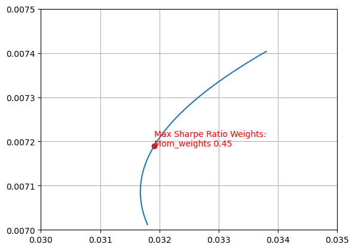

```python
plt.plot(df_eff['port_std'], df_eff['port_mean'])
plt.scatter(df_eff.loc[idx, 'port_std'], df_eff.loc[idx, 'port_mean'], c = 'red')
plt.text(df_eff.loc[idx, 'port_std'],
         df_eff.loc[idx, 'port_mean'],
         s = 'Max Sharpe Ratio Weights:\nMom_weights {:.2f}'.format(df_eff.loc[idx, 'mom_weights']),
         c = 'red')
plt.xlim(0.03, 0.035)
plt.ylim(0.007, 0.0075)
plt.grid()
plt.show()
```

```python
weight_mom = 0.5
weight_regime = 0.5
df_total_weights = (weight_mom*df_mom_weights + weight_regime*df_regime_weights).dropna()
```

```python
information_correlation = df_total_weights.corrwith(df_logReturn,  axis=1, method = 'spearman').dropna()
information_correlation.loc[test_indices].mean()
```

```
0.07700534759358289
```

```python
def getResult(df_results):
    df_results['Excess_Return'] = df_results['Portfolio_Return'] - df_results['Benchmark_Return']
    port_mean = 12*df_results['Portfolio_Return'].mean()
    port_std = np.sqrt(12)*(df_results['Portfolio_Return'].std())
    bench_mean = 12*df_results['Benchmark_Return'].mean()
    bench_std =  np.sqrt(12)*(df_results['Benchmark_Return'].std())
    excess_mean = 12*df_results['Excess_Return'].mean()
    info_std = np.sqrt(12)*(df_results['Excess_Return'].std())
    sharpe_ratio = port_mean/ port_std
    info_ratio = excess_mean/info_std
    hit_ratio = sum(df_results['Excess_Return'] > 0)/len(df_results)

    x_values = sorted(np.array(df_results['Benchmark_Return'].dropna()))
    plt.scatter(df_results['Benchmark_Return'], df_results['Portfolio_Return'], s = 1.5)
    plt.xlabel('Benchmark_Return')
    plt.ylabel('Portfolio_Return')
    plt.plot(x_values, x_values, label='y = x', c = 'orange')
    plt.grid()
    plt.show()

    return pd.DataFrame({
        'port_mean': port_mean,
        'port_std':port_std,
        'bench_mean':bench_mean,
        'bench_std':bench_std,
        'excess_mean':excess_mean,
        'tracking_error':info_std,
        'sharpe_ratio':sharpe_ratio,
        'info_ratio':info_ratio,
        'hit_ratio':hit_ratio,
           }, index = ['Result'])
```

```python
df_results = pd.DataFrame()
total_return = (df_total_weights*df_logReturn).dropna().sum(axis = 1)
# benchmark_return = 0.5/6*df_logReturn.iloc[:, 0:6].sum(axis = 1) \
#     +0.3*df_logReturn[['US IG corporate bonds index', 'US 10-year Treasury Bond Index','US 3-month T-bill Index']].sum(axis=1)\
#     +0.2*df_logReturn[['GSCI commodity index']].sum(axis = 1)
benchmark_return = df_logReturn.mean(axis = 1)
df_results = pd.concat((total_return, benchmark_return), axis = 1)
df_results.columns = ['Portfolio_Return', 'Benchmark_Return']
df_results = df_results.dropna()
df_results
```

| Dates | Portfolio_Return | Benchmark_Return |
| --- | --- | --- |
| 1995-08-31 | 0.002017 | 0.006112 |
| 1995-09-29 | 0.033515 | 0.026098 |
| 1995-10-31 | 0.008494 | 0.004616 |
| 1995-11-30 | 0.032734 | 0.030330 |
| 1995-12-29 | 0.017867 | 0.020375 |
| ... | ... | ... |
| 2023-03-31 | 0.019628 | 0.017056 |
| 2023-04-28 | 0.009737 | 0.006566 |
| 2023-05-31 | -0.012322 | -0.014585 |
| 2023-06-30 | 0.052126 | 0.038687 |
| 2023-07-31 | 0.032125 | 0.028060 |

336 rows × 2 columns

# Final Result

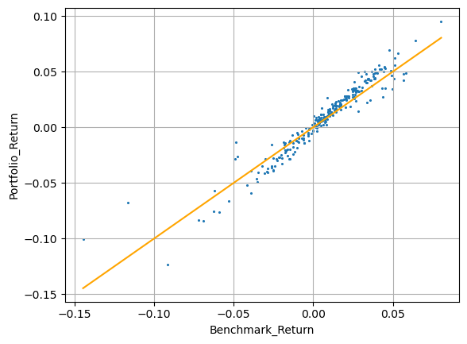

|  | port_mean | port_std | bench_mean | bench_std | excess_mean | tracking_error | sharpe_ratio | info_ratio | hit_ratio | info_corr |
| --- | --- | --- | --- | --- | --- | --- | --- | --- | --- | --- |
| Result | 0.105297 | 0.108934 | 0.083848 | 0.098714 | 0.02145 | 0.031127 | 0.966617 | 0.689085 | 0.641791 | 0.151606 |

```python
#Training Data Result
Tra_rest = getResult(df_results.loc[train_df.index].dropna())
Tra_rest['info_corr']=information_correlation.loc[train_indices].mean()
Tra_rest
```

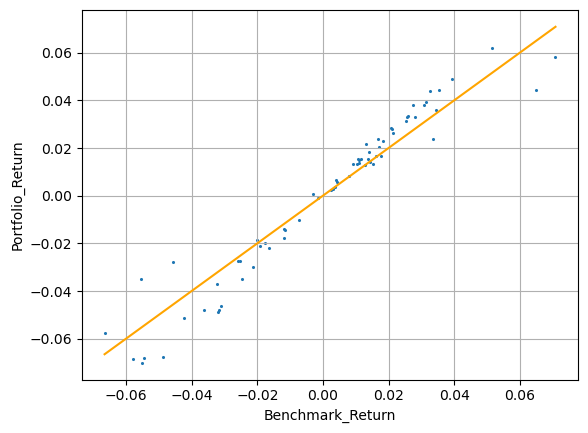

|  | port_mean | port_std | bench_mean | bench_std | excess_mean | tracking_error | sharpe_ratio | info_ratio | hit_ratio | info_corr |
| --- | --- | --- | --- | --- | --- | --- | --- | --- | --- | --- |
| Result | 0.012376 | 0.117216 | 0.012649 | 0.104478 | -0.000273 | 0.029681 | 0.10558 | -0.009208 | 0.558824 | 0.077005 |

```python
#Testing Data Result
Test_rest = getResult(df_results.loc[test_df.index].dropna())
Test_rest['info_corr']=information_correlation.loc[test_indices].mean()
Test_rest
```

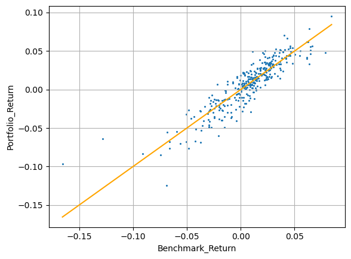

[output not shown]

```python
#unconditional resutl
getResult(df_results)
```